# Red Wine quality exploration by Zhengda He

This report explores the red wine quality dataset, which public available for research.

The goal of this report is to explore Which chemical properties influence the quality of red wines.

# Univariate Plots Section

```
## 'data.frame':    1599 obs. of  13 variables:
##  $ X                   : int  1 2 3 4 5 6 7 8 9 10 ...
##  $ fixed.acidity       : num  7.4 7.8 7.8 11.2 7.4 7.4 7.9 7.3 7.8 7.5 ...
##  $ volatile.acidity    : num  0.7 0.88 0.76 0.28 0.7 0.66 0.6 0.65 0.58 0.5 ...
##  $ citric.acid         : num  0 0 0.04 0.56 0 0 0.06 0 0.02 0.36 ...
##  $ residual.sugar      : num  1.9 2.6 2.3 1.9 1.9 1.8 1.6 1.2 2 6.1 ...
##  $ chlorides           : num  0.076 0.098 0.092 0.075 0.076 0.075 0.069 0.065 0.073 0.071 ...
##  $ free.sulfur.dioxide : num  11 25 15 17 11 13 15 15 9 17 ...
##  $ total.sulfur.dioxide: num  34 67 54 60 34 40 59 21 18 102 ...
##  $ density             : num  0.998 0.997 0.997 0.998 0.998 ...
##  $ pH                  : num  3.51 3.2 3.26 3.16 3.51 3.51 3.3 3.39 3.36 3.35 ...
##  $ sulphates           : num  0.56 0.68 0.65 0.58 0.56 0.56 0.46 0.47 0.57 0.8 ...
##  $ alcohol             : num  9.4 9.8 9.8 9.8 9.4 9.4 9.4 10 9.5 10.5 ...
##  $ quality             : int  5 5 5 6 5 5 5 7 7 5 ...
```

```
##        X          fixed.acidity   volatile.acidity  citric.acid
##  Min.   :   1.0   Min.   : 4.60   Min.   :0.1200   Min.   :0.000
##  1st Qu.: 400.5   1st Qu.: 7.10   1st Qu.:0.3900   1st Qu.:0.090
##  Median : 800.0   Median : 7.90   Median :0.5200   Median :0.260
##  Mean   : 800.0   Mean   : 8.32   Mean   :0.5278   Mean   :0.271
##  3rd Qu.:1199.5   3rd Qu.: 9.20   3rd Qu.:0.6400   3rd Qu.:0.420
##  Max.   :1599.0   Max.   :15.90   Max.   :1.5800   Max.   :1.000
##  residual.sugar     chlorides       free.sulfur.dioxide
##  Min.   : 0.900   Min.   :0.01200   Min.   : 1.00
##  1st Qu.: 1.900   1st Qu.:0.07000   1st Qu.: 7.00
##  Median : 2.200   Median :0.07900   Median :14.00
##  Mean   : 2.539   Mean   :0.08747   Mean   :15.87
##  3rd Qu.: 2.600   3rd Qu.:0.09000   3rd Qu.:21.00
##  Max.   :15.500   Max.   :0.61100   Max.   :72.00
##  total.sulfur.dioxide    density             pH          sulphates
##  Min.   :  6.00       Min.   :0.9901   Min.   :2.740   Min.   :0.3300
##  1st Qu.: 22.00       1st Qu.:0.9956   1st Qu.:3.210   1st Qu.:0.5500
##  Median : 38.00       Median :0.9968   Median :3.310   Median :0.6200
##  Mean   : 46.47       Mean   :0.9967   Mean   :3.311   Mean   :0.6581
##  3rd Qu.: 62.00       3rd Qu.:0.9978   3rd Qu.:3.400   3rd Qu.:0.7300
##  Max.   :289.00       Max.   :1.0037   Max.   :4.010   Max.   :2.0000
##     alcohol         quality
##  Min.   : 8.40   Min.   :3.000
##  1st Qu.: 9.50   1st Qu.:5.000
##  Median :10.20   Median :6.000
##  Mean   :10.42   Mean   :5.636
##  3rd Qu.:11.10   3rd Qu.:6.000
##  Max.   :14.90   Max.   :8.000
```

### Quality

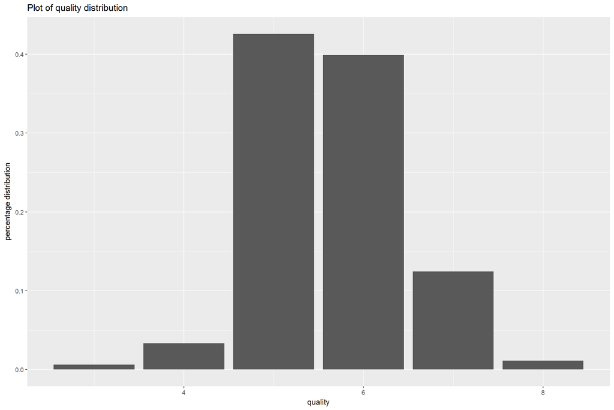

```
## [1] "summary of wine quality"
```

```
##    Min. 1st Qu.  Median    Mean 3rd Qu.    Max.
##   3.000   5.000   6.000   5.636   6.000   8.000
```

```
## [1] "distribution of wine quality"
```

```
##
##   3   4   5   6   7   8
##  10  53 681 638 199  18
```

From the plot and statistical data we could see that over 80% sample of our quality level falls in 5 or 6. Nearly 95% falls in level 5,6 or 7.

### Fix acid

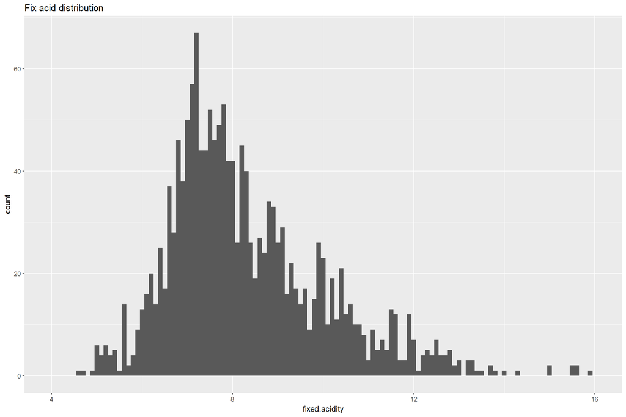

```
##    Min. 1st Qu.  Median    Mean 3rd Qu.    Max.
##    4.60    7.10    7.90    8.32    9.20   15.90
```

Fixed acidity is the measurement of tartaric acid (g/dm^3) in the wine.

### Volatile acidity"

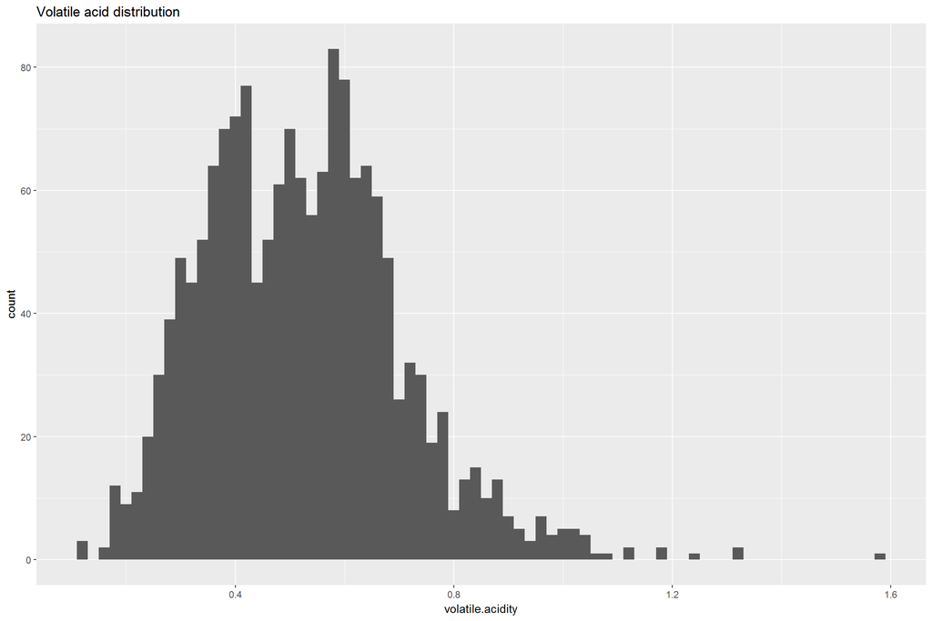

```
##    Min. 1st Qu.  Median    Mean 3rd Qu.    Max.
##  0.1200  0.3900  0.5200  0.5278  0.6400  1.5800
```

Volatile acidity is the measurement of acetic acid (g/dm^3) in the wine.

### Citric acid

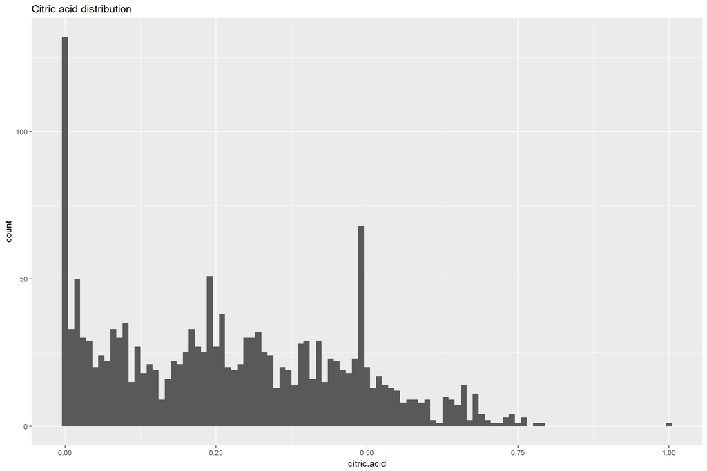

```
##    Min. 1st Qu.  Median    Mean 3rd Qu.    Max.
##   0.000   0.090   0.260   0.271   0.420   1.000
```

```
## [1] "number of 0 citric acid:  132"
```

```
## [1] "number of 0 citric acid:  1"
```

citric acid is the measurement of citric acid (g/dm^3) in the wine.

From the plot we could clearly see there is a spike on the left of the plot, which indicates that there are over 100 sample in this dataset has 0 citric acid measurement.From console output we know that there is 1 sample has citric acid 1 and 132 sample with citric acid value 0.

### Residual sugar

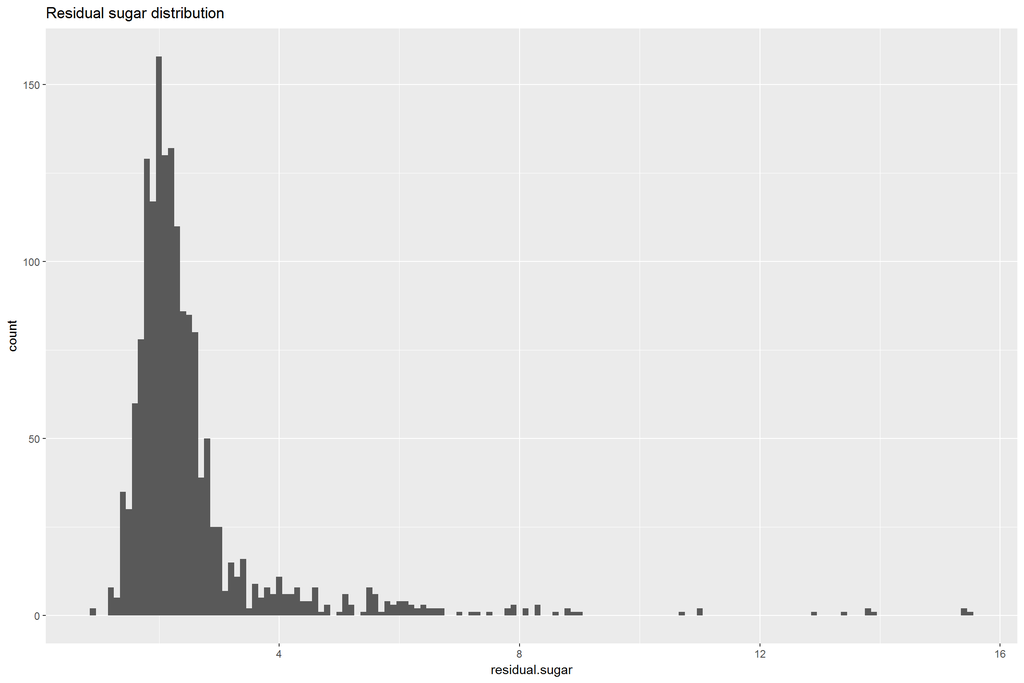

```
##    Min. 1st Qu.  Median    Mean 3rd Qu.    Max.
##   0.900   1.900   2.200   2.539   2.600  15.500
```

```
## [1] "3rd quatile + 1.5*IRQ =  3.65"
```

```
## [1] "number of point could be considered as outlier: 155"
```

Residual sugar is the amount of sugar remaining after fermentation stops in the wine, it measures in (g/ dm^3)  
From the plot we could see most of our sample falls in the low sugar region.

Through statistical analysis we found that IRQ = 0.7,while 3rd quatile value is 2.6, any point beyond the value (2.6+0.7*1.5) = 3.65 could be considered as outlier.

Thus we could plot this again with proper range(1-4)

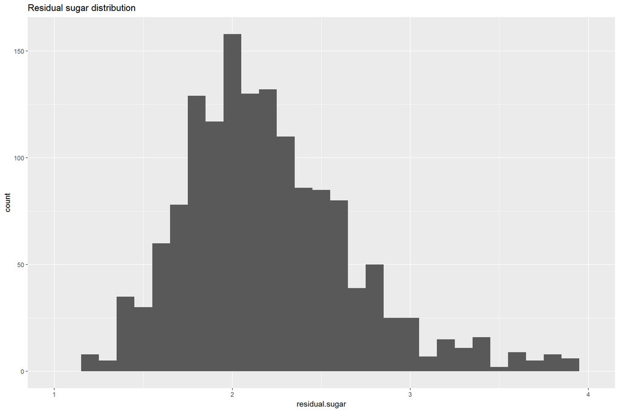

This looks much better now.

### chlorides

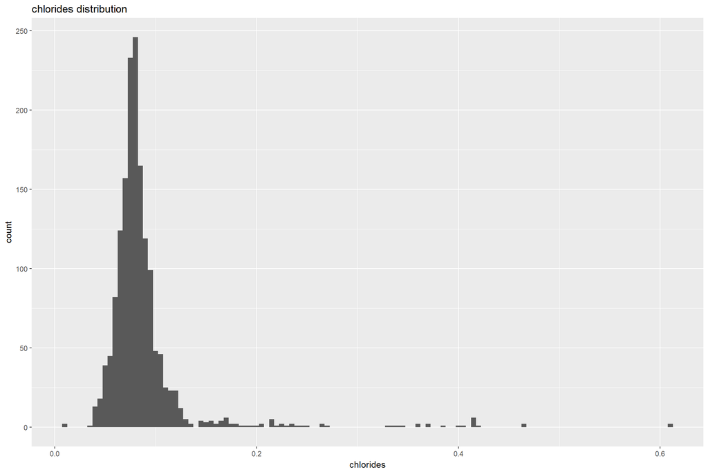

```
##    Min. 1st Qu.  Median    Mean 3rd Qu.    Max.
## 0.01200 0.07000 0.07900 0.08747 0.09000 0.61100
```

```
## [1] "3rd quatile + 1.5*IRQ =  0.12"
```

[output not shown]

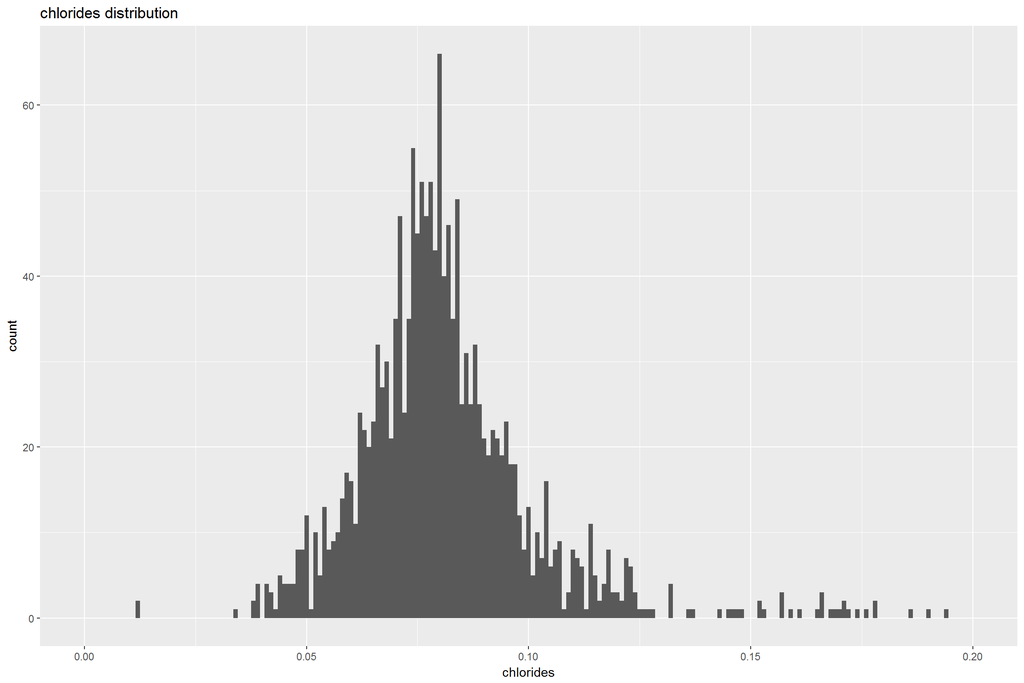

This looks much better now

### Free sulfur dioxide

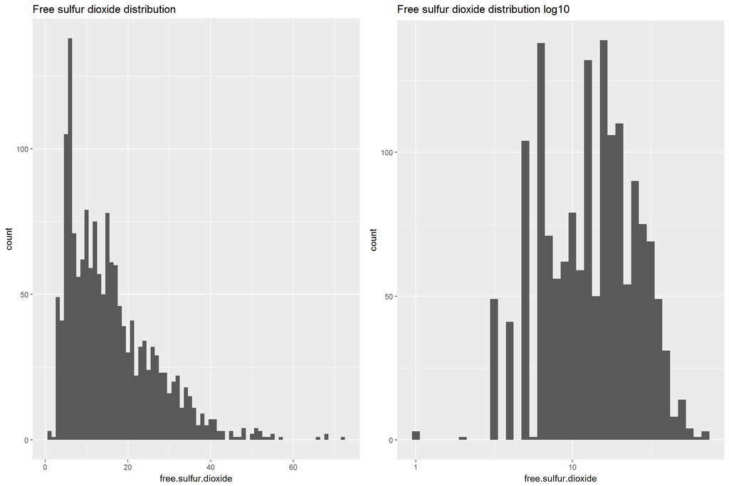

```
##    Min. 1st Qu.  Median    Mean 3rd Qu.    Max.
##    1.00    7.00   14.00   15.87   21.00   72.00
```

### Total sulfur dioxide

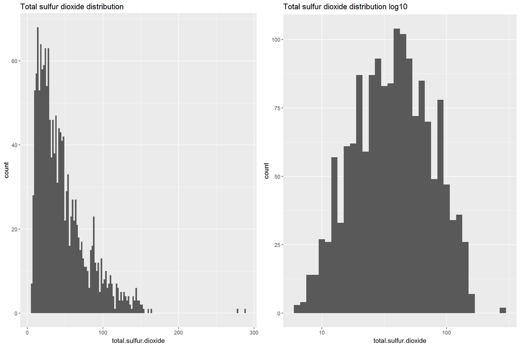

```
##    Min. 1st Qu.  Median    Mean 3rd Qu.    Max.
##    6.00   22.00   38.00   46.47   62.00  289.00
```

Total sulfur dioxide is amount of free and bound forms of S02.

### Density

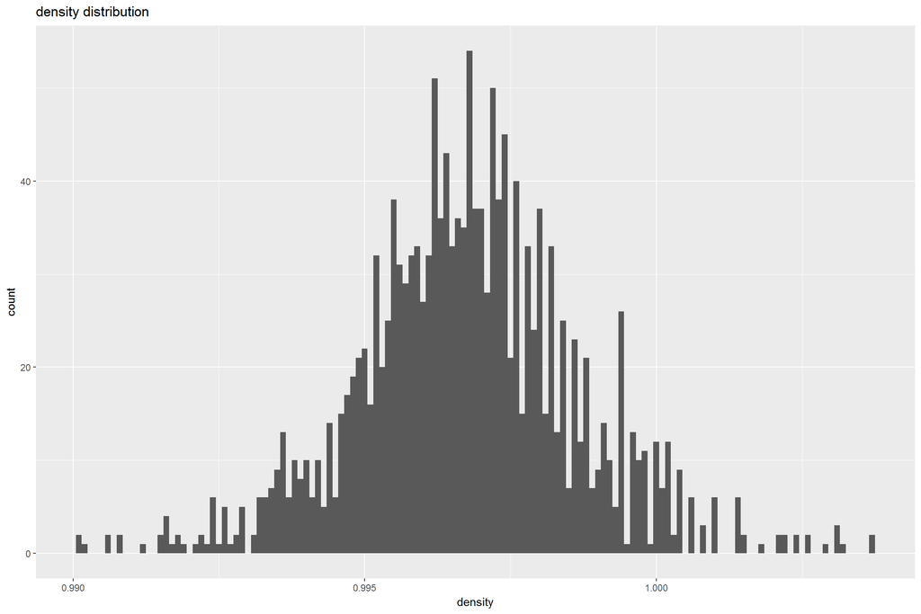

```
##    Min. 1st Qu.  Median    Mean 3rd Qu.    Max.
##  0.9901  0.9956  0.9968  0.9967  0.9978  1.0040
```

Density represents the density of the wine measure in (g / cm^3).  
The density variable has a comparatively normal distribution, centered on 1g/cm^3(which is the density of water)

### pH

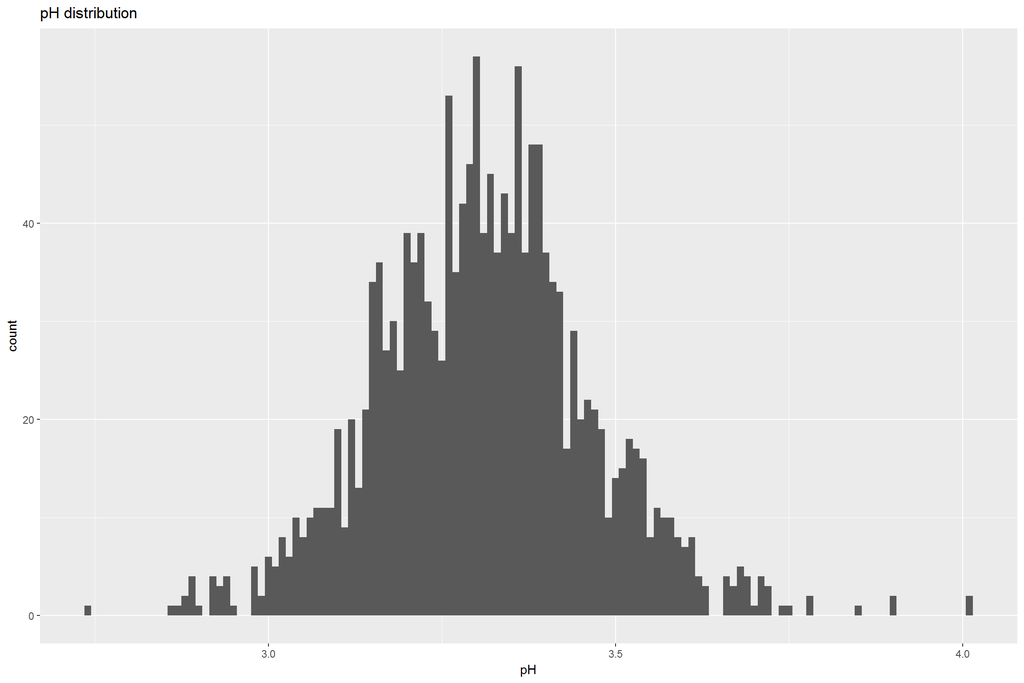

```
##    Min. 1st Qu.  Median    Mean 3rd Qu.    Max.
##   2.740   3.210   3.310   3.311   3.400   4.010
```

pH describes how acidic or basic a wine is on a scale from 0 (very acidic) to 14 (very basic).

Similar to density, pH also has a faily normal distribution.

### sulphates

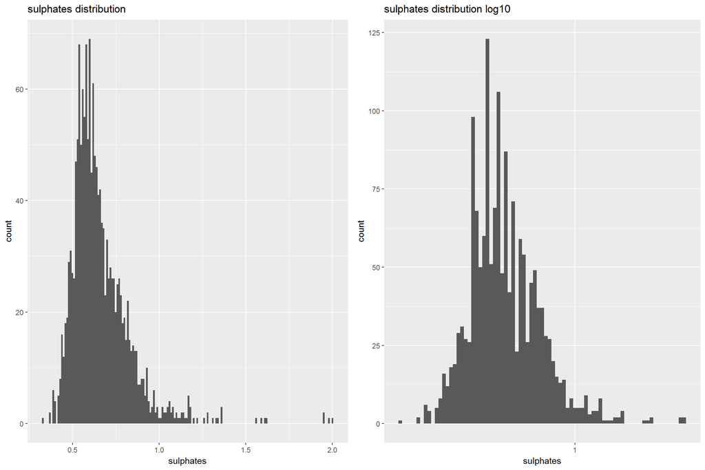

```
##    Min. 1st Qu.  Median    Mean 3rd Qu.    Max.
##  0.3300  0.5500  0.6200  0.6581  0.7300  2.0000
```

sulphates is a wine additive which can contribute to sulfur dioxide gas (S02) levels, wich acts as an antimicrobial and antioxidant.

Take log10 on the x aixs make it have more normal distribution.

### alcohol

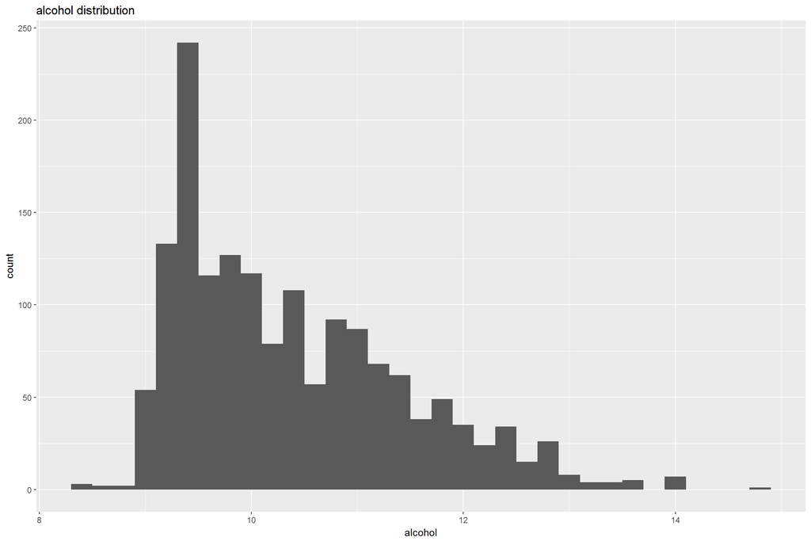

```
##    Min. 1st Qu.  Median    Mean 3rd Qu.    Max.
##    8.40    9.50   10.20   10.42   11.10   14.90
```

Alcohol refers to the percent alcohol content of the wine, with % by volume.

# Univariate Analysis

### What is the structure of your dataset?

This is a tidy dataset, with 1599 observation on red wine quality and its chemical characteristics.

### What is/are the main feature(s) of interest in your dataset?

The main feature of interest in the dataset should be the quality of red wine, the goal of this exploration is to figure out how other feature affect the quality feature.

### What other features in the dataset do you think will help support your investigation into your feature(s) of interest?

From the description in the dataset, it seems all 11 feature could affect the taste of the wine,thus influence the quality of the wine.

### Of the features you investigated, were there any unusual distributions? Did you perform any operations on the data to tidy, adjust, or change the form of the data? If so, why did you do this?

I did not make any modification on the dataset, since this is a pretty tidy dataset, with no missing value, and all the feartures seems to independent to each other.

# Bivariate Plots Section

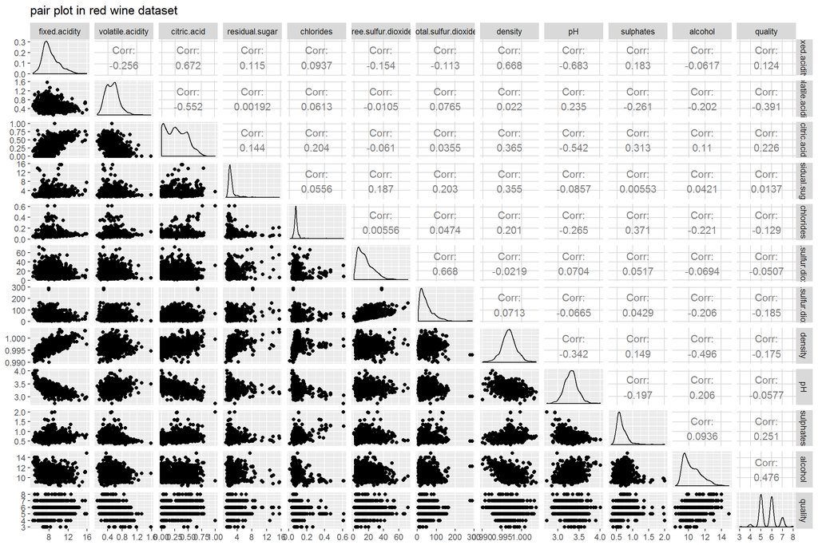

From the ggpair plot we could see that there are clearly some feature has correlation with quality.

Alcohol seems affect the most(correlation 0.476), followed by volatile acidity(correlation -0.391). Although affect the most, the correlation score is not high(beyong 0.7) which indicates that it is not strong correlated.

Then is slightly low correlated feature, includes:sulphates( correlation 0.251) and citric acid(correlation 0.226) Other features, which below correlation +-0.2, are considered no correlation with quality.

### Alcohol Vs Quality

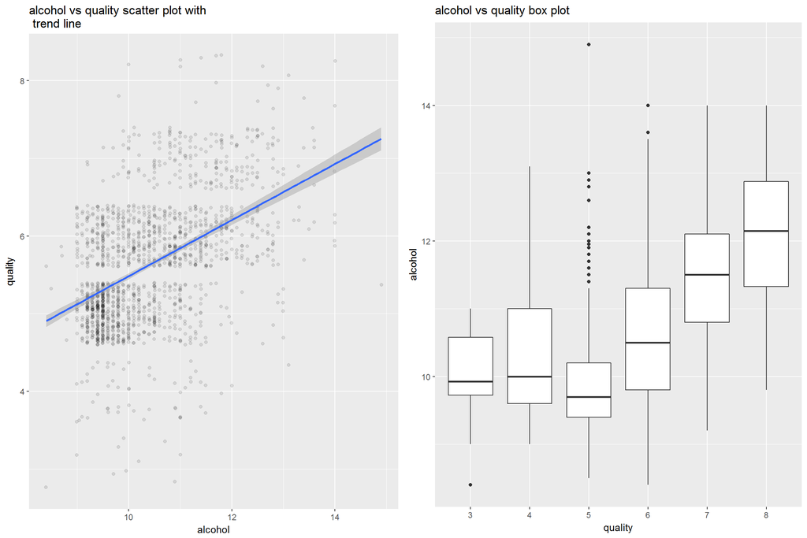

Scatter plot with smooth line above shows the relationship between quality and alcohol, who has the most correlation with quality.

The smooth line indicates the overall correlation of quality and alcohol.

Box plot above also reveals the overall trends: Higher quality the wine has, higher alcohol it contains.

### volatile acidity Vs Quality

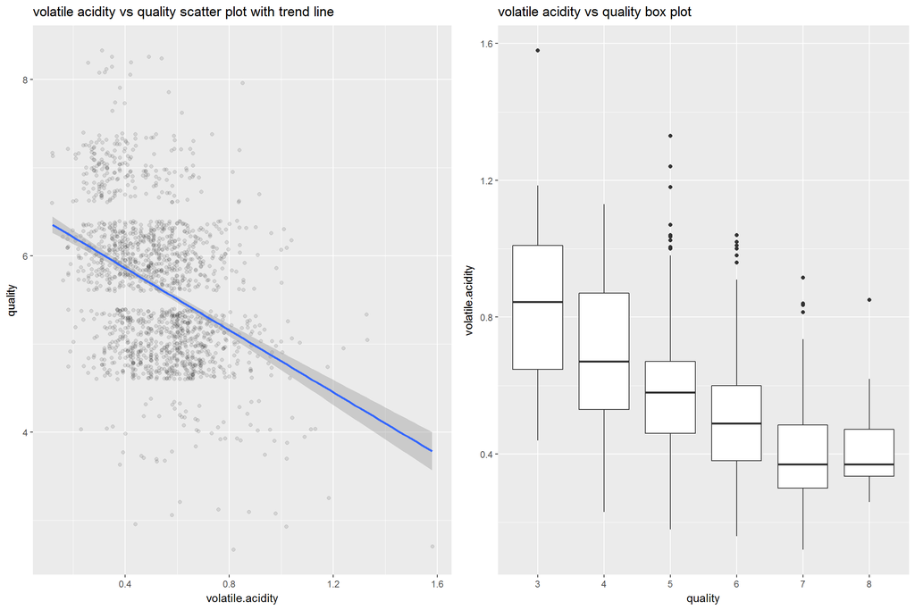

Similar to plot in quality vs alcohol, the the points from scatter point could help visualizing the distribution of our samples. Smooth line could be viewed as trend line, help visualizing the correlation of the two features. Box plot could help visualizing statistic data in different group.

In the plot above, we could see that volatile acidity and quality are negatively correlated, which demostrated the correlation score.

### sulphates Vs Quality and Citric acid vs Quality

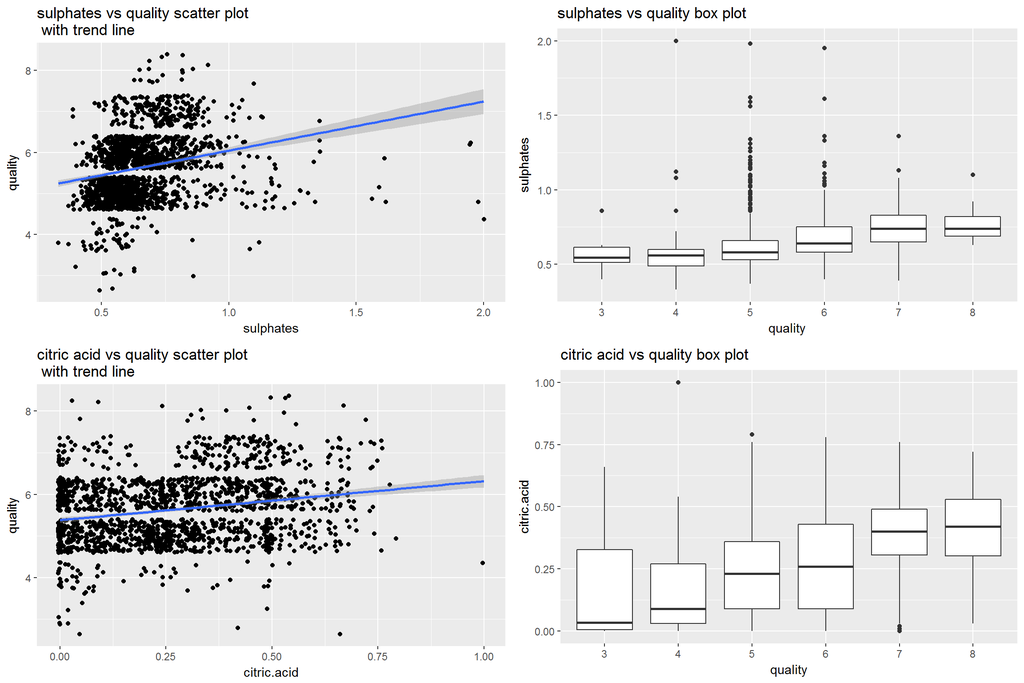

These are both low correlation feature with quality.  
From the plot we could see they are both positively correlated with quality, but the slope of trend line will drop down, as the correation decreases.

# Bivariate Analysis

### Talk about some of the relationships you observed in this part of the investigation. How did the feature(s) of interest vary with other features in the dataset?

Quality tend to change its value with the change of other features, but not significant in our sample dataset.

### Did you observe any interesting relationships between the other features (not the main feature(s) of interest)?

From ggpair plot we could find some strong correlations, such as density vs fix acidity(0.668), pH vs fix acidity(-0.683),total sulfur dioxide vs free sulful dioxide(0.668), and all of these seems to make sense.

### What was the strongest relationship you found?

Alcohol, with correlation score 0.476

# Multivariate Plots Section

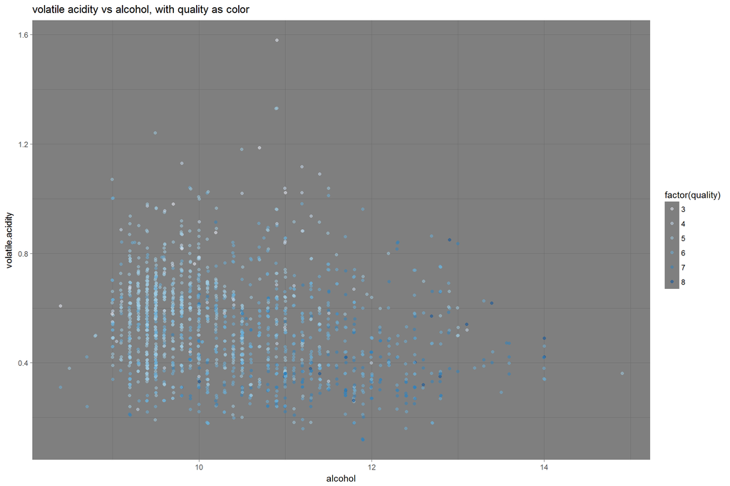

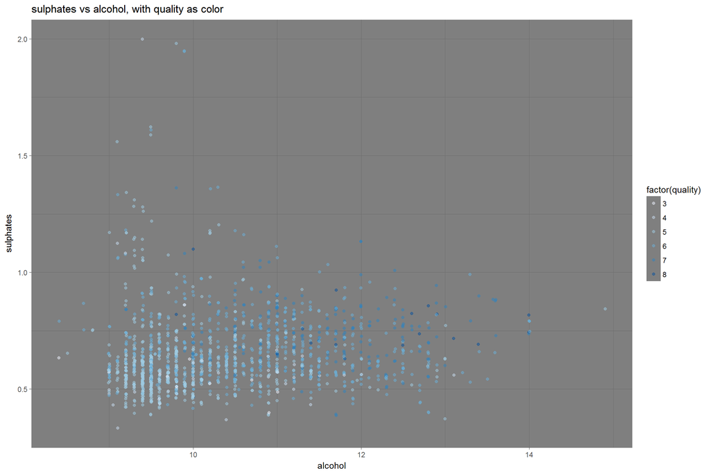

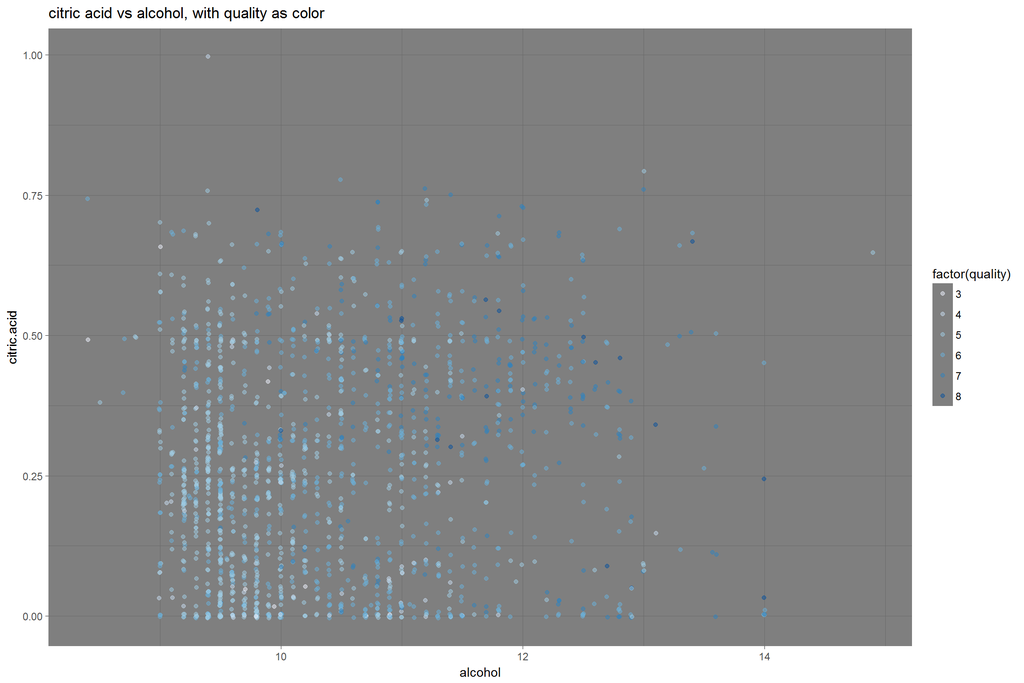

### Talk about some of the relationships you observed in this part of the investigation. Were there features that strengthened each other in terms of looking at your feature(s) of interest?

The Multivariate Plots section didn’t give us any new knowledge by visuliazing the data in a new way, it demostrated that our investigation on Bivariate section is sound.

By visuliazing the dataset in this way, we could see the positive correlation between quality and alcohol(quality 5 most falls in alcohol range 8-11, quality 6 most falls in range 10-12), negative correlation between quality and volatile acidity etc.

In one word, visuliazing in this way strengthened our findings in bivariable section.

# Final Plots and Summary

### Plot One

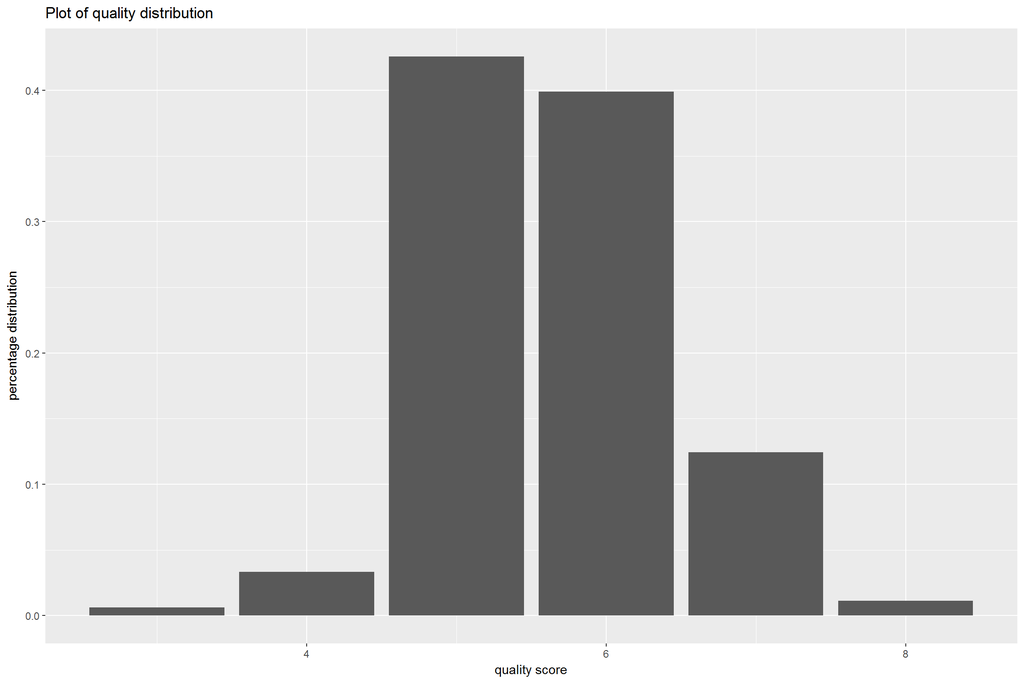

### Description One

This plot shows the distribution of the overall quality in our dataset.

It tells us that the quality feature is heavily biased, with half of its range(3,4,8) take around only 5% sample and another half (5,6,7) take around 95% sample of our dataset.

### Plot Two

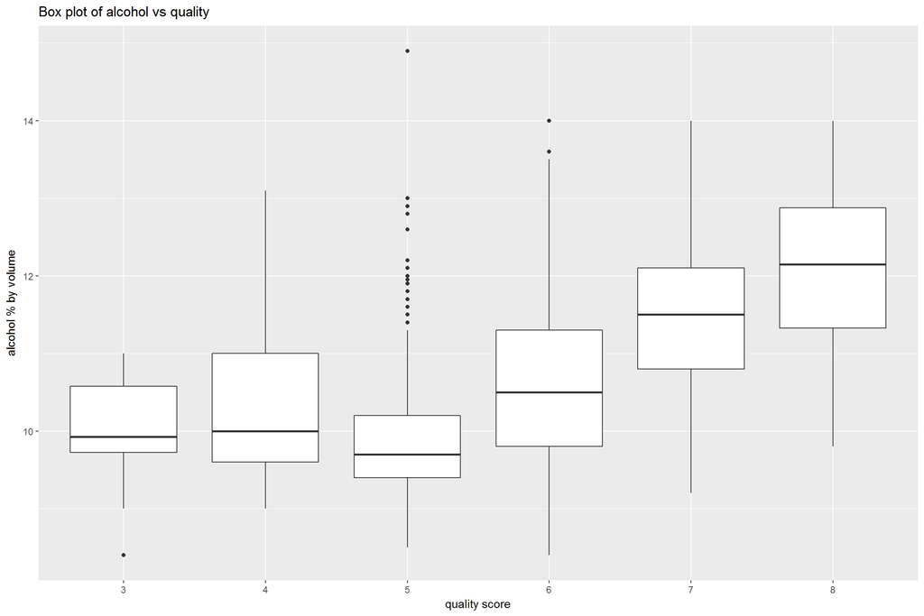

### Description Two

This plot shows the correlation between quality and alcohol.

Alcohol have the most correlation with quality in our dataset, and the plot shows the positive correlation between quality and alcohol clearly.

### Plot Three

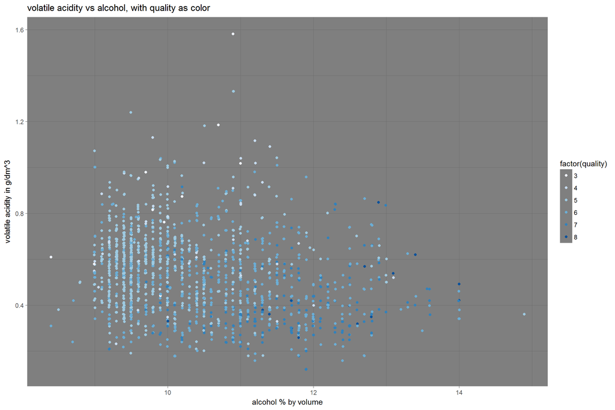

### Description Three

This plot shows distribution of quality with alcohol as x aixs and volatile acidity as y axis.

# Reflection

The red wine dataset contains information on 1599 sample of wine, with 11 chemical feature describe its chemical characteristic and quality feature describe how good it is from peoples taste.

From the exploration we first plot every single feqature distribution. Then we have ggpair plot which plot every pair of feature in our dataset.  
From the ggpair plot we know some of the feature may have more chance to correlate with quality(alcohol: 0.476,volatile acidity:-0.391,sulphates:0.251 and citric acid:0.226 ).  
From bivariable plot we demostrated the correlation between quality and other feature, and multivariable plot strenthen our conclusion on the correation.

From the exploration and analysis we found that this dataset is highly biased:  
In quality feature, 95% of our sample within range (5,6,7), 82% of our sample are within range(5,6).  
Also, for the residual sugar feature, in the dataset variable description it says:“wines with greater than 45 grams/liter are considered sweet”. But in the dataset, the highest value for this feature is around 16 g/liter, which means in our dataset no wine sample could be considered as sweet.  
Highly biased sampling make result of this dataset analysis not general. In another word, conclusion draw from this analysis could not apply to other red wine dataset.

Also since I’m not familiar with chemistry, I know really little about most of the feature in the dataset, thus may not able to dig deep into the dataset and find the story the data tell.

For the future work, I think we should have bigger and more balanced dataset(e.g. more sweet wine sample), thus we could make our analysis general. Also I think I could learn some field knowledge, to know more about how each feature could affect the wine quality.